# Report on final run of complete experiment

Michael

02/5/2019

## Data collection and design

103 participants were drafted on Prolific to do the complete experiment. On each start of the experiment, participants where randomly assigned to one of three conditions:

1. cooperative play with a literal co-player
2. competitive play with a level-0 (semantic/unstrategic) co-player
3. competitive play with a level-1 (anti-semantic/strategic) co-player

The experiment consisted of (in order) the following parts:

1. instructions
2. color blindness test
3. 4 training trials in the role as guesser
4. 18 training trials in describer role with feedback
   - the feedback was auto-generated and corresponded to a literal interpreting agent (‘cooperative’ and ‘unstrategic condition’) or an agent who inverts the semantic meaning of descriptions (‘strategic condition’)
   - this training round used the /all/ and /none/ data from the main trial (reused exact same pictures)
5. 36 trials of the sentence completion w/o feedback (main task)
6. self-assessment of performance in main task
7. truth-value judgement task
   - participants were asked to rate how they believed the co-player interpreted sentences

Payment was 2.5 pounds for compensation plus 0.75 pounds bonus. The bonus was announced to be dependent on performance in the card-playing task, but evenutally paid to everyone. The average time spent on the whole experiment (including reading instructions, and completing the post-experiment survey) was 23.41 minutes.

The experiment can be examined [here](https://michael-franke.github.io/misleading_with_underinfo/experiments/06_sentence_select_with_training/index.html).

The motivation for an initial training-with-feedback round is to induce in the participants a particular belief about the behavior of the co-player. This is to reduce degrees of freedom in the eventual interpretation of participants behavior in the main task. Consequently, we will be interested chiefly in the behavior of participants who learned to predict the co-player’s choices during training. Indeed, we will exclude from the analysis participants who did not perform well enough during training, since for these participants it is hard to say which choices count as rational or random. We will also use the data from the TVJ task to further classify participants based on their beliefs about the co-player’s interpretation of sentences involving potential implicature triggers. In total four types of participants will be distinguished along two binary classifications, namely (i) those that expect the co-player to interpret semantically vs. pragmatically and (ii) those that expect the co-player to interpret strategically (non-literally) vs unstrategically (literally).

Focusing on the participants who mastered the training (learned about the co-player’s behavior), we would like to know the extend to which participants play the “winning move” of the respective experimental condition. The **winning move** of each condition is the move which, given the co-player behavior displayed during training, would lead to winning the round. In implicature trials, the “winning move” includes assuming that the co-player calculates the implicature. (So, with a strategic co-player in the competitive condition, the winning move assumes that the co-player calculates the implicature and therefore chooses the opposite card, of which the implicature meaning is not true).

The second question can really only be answered based on the choice data from the main task, if we know more about the participants’ likely beliefs about their opponent. For that reason, we take the types described above into account. We expect to be able to see a strategic use of implicature meaning only for those participants who believe that their opponent computes implicatures and who understood whether their opponent is literal or strategic (level-0 vs level-1).

## Exploring the data

Here’s what participants commented:

```r
d$comments %>% unique
```

```
##  [1] NA
##  [2] "Not at this moment"
##  [3] "good study, thanks"
##  [4] "Thank you :) Very entertaining study!"
##  [5] "I thought it was kinda weird that my opponent always ate up everything I chose as the truth, but it turns out it was a bot in the end. Maybe randomizing the opponent's choices would be a better choice."
##  [6] "This was an interesting \"game\"! In the latter part, I did make a couple of mistakes in the true/false category, but I doubt that would skew things much."
##  [7] "interesting study"
##  [8] "Awesome survey."
##  [9] "None"
## [10] "no comments"
## [11] "It was fun but longer that the recommended time"
## [12] "I LIKED THE GAME"
## [13] "I've noticed that something was not right since in the training round when a lie was told the round was lost."
## [14] "Thank you a very thought provoking survey and no offence taken about being deceptive it was very interesting ."
## [15] "i enjoyed trying to 'second guess' my opponent. I would love to know whether I managed to trick them. Not sure how I feel about it not being a real person!"
## [16] "It did cross my mind whether I was not playing against a human but I ultimately did, it definitely made me focus on the task and consider someone else's perspective on answering the second part"
## [17] "Very interesting"
## [18] "it was an interesting survey enjoyed doing it."
## [19] "Nothing, thank you."
## [20] "none"
## [21] "Sorry if I messed up on some of the \"most\" true or false questions as some of them I though yeah it's technically true but all are?"
## [22] "i did think it was strange as the other player got all the questions wrong in the practice, therefore in the true and false round i used to incorrect answers thinking this is what the other person would be thinking too"
## [23] "Thoroughly enjoyed this study. Thank you"
## [24] "None, thank you."
## [25] "None."
## [26] "Cool Experiment"
## [27] "I did think I was against a computer as the response was fairly quick and would've thought this survey was applied the same to everyone who uses it. Couldn't have asked the same questions given to me to the player on the other side?"
## [28] "No"
## [29] "Fun study!"
```

Here’s the outcome of the (randomized) allocation to ‘strategic’ vs. ‘unstrategic’ co-players (training set).

```r
show(table(d$coplayer_type)/122)
```

[output not shown]

## Data preparation

We looked at the behavior of each participant in the training & TVJ tasks. We want to classify each participant based on successful/unsuccessful training and a semantic/pragmatic type.

### Color blindness

We first look at answers to the colorblindness test and add that to our data set:

```r
color_blindness = filter(d, trial_type == "color_blindness_test") %>%
  select(submission_id, correct, response) %>%
  mutate(correct = ifelse(correct == response,1,0)) %>%
  group_by(submission_id) %>%
  summarize(color_blind = mean(correct) < 1)
color_blindness_failures = filter(color_blindness, color_blind == TRUE) %>% pull(submission_id)
message("Number of failures on color blindness test: ", length(color_blindness_failures))
```

```
## Number of failures on color blindness test: 13
```

```r
## exclude color blind participants right away?
# d = filter(d, ! submission_id %in% color_blindness_failures)

# add info to full data set
d = full_join(d, color_blindness, by = "submission_id")
```

Here’s the kind of answers that people who “failed”" the colorblindness test gave:

```r
d %>% filter(color_blind == TRUE, trial_type == "color_blindness_test") %>%
  unique() %>% select(submission_id, correct, response) %>%
  spread(key = correct, value = response)
```

```
## # A tibble: 13 x 4
##    submission_id `12`  `45`  `73`
##            <dbl> <chr> <chr> <chr>
##  1          7813 12    45    23
##  2          7830 12    45    23
##  3          7831 12    45    23
##  4          7837 12    45    13
##  5          7840 12    45    13
##  6          7846 12    45    23
##  7          7848 12    45    13
##  8          7850 12    45    13
##  9          7858 12    45    78
## 10          7859 12    45    23
## 11          7865 12    45    13
## 12          7875 12    45    13
## 13          7877 12    45    23
```

We see that nobody appears to be completely color blind. It might be justify not to exclude anybody based on misperceiving 73 as 13, 23 or 78. At least, nobody wrote “none”, which as the response they were instructed to give if they did not perceive any number.

### Training phase

```r
success_threshold = 0.4

d_training = filter(d, trial_type == "sentence_completion_training")

d_training_summary = d_training %>%
  mutate(winning_move = ifelse(coplayer_type == "unstrategic", "red", "green"),
         winning_move_chosen = ifelse(winning_move == response, 1, 0),
         loosing_move = ifelse(coplayer_type == "unstrategic", "green", "red"),
         loosing_move_chosen = ifelse(loosing_move == response, 1, 0),
         distractor_move_chosen = ifelse(response == "false", 1, 0)) %>%
  group_by(submission_id, coplayer_type, condition) %>%
  summarize(win = mean(winning_move_chosen),
            loose = mean(loosing_move_chosen),
            dstrct = mean(distractor_move_chosen)) %>%
  ungroup() %>%
  gather(key = response, value = proportion, win, loose, dstrct) %>%
  mutate(new_col_names = paste0("train_", condition, "_", response)) %>%
  select(submission_id, new_col_names, proportion) %>%
  spread(key = new_col_names, value = proportion) %>%
  group_by(submission_id) %>%
  mutate(training_successful = ifelse(mean(c(train_all_win, train_none_win)) > success_threshold, 1, 0)) %>%
  ungroup()

d = full_join(d, d_training_summary, by = "submission_id")
```

Let’s look at how many people learned their opponent’s type during training:

```r
message("Nr learned from training?")
```

```
## Nr learned from training?
```

```r
d %>% select(submission_id, coplayer_type, training_successful) %>%
  unique() %>%
  group_by(coplayer_type, training_successful) %>%
  summarize(count = n()) %>% show()
```

```
## # A tibble: 5 x 3
## # Groups:   coplayer_type [3]
##   coplayer_type training_successful count
##   <chr>                       <dbl> <int>
## 1 cooperative                     1    39
## 2 strategic                       0     6
## 3 strategic                       1    25
## 4 unstrategic                     0    11
## 5 unstrategic                     1    22
```

It seems that learning is easiest in the cooperative condition, and hardest in the competitive condition with an unstrategic opponent, but that is only by inspection and not particularly relevant.

### TVJ

To classify participants as (expecting) semantic or pragmatic (co-player interpretations), we look at the overal proportion of semantic (/true/) responses to implicature items /some/ and /most/. If this exceeds the threshold `semprag_threshol`, participants are classified as semantic responders. We also check participants behavior on the control items, and consider a participant ready for exclusion if their performance in the controls is below the `control_threshold`.

```r
control_threshold = 0.7
semprag_threshold = 0.5

d_tvj = filter(d, trial_type == "truth_value_judgements") %>%
  mutate(response = ifelse(response == "true", 1, 0))

d_tvj_summary = d_tvj %>%
  group_by(submission_id, trigger, condition) %>%
  summarize(mean_true = mean(response)) %>%
  arrange(submission_id) %>%
  ungroup() %>%
  mutate(new_col_names = paste0("tvj_", trigger, "_", condition)) %>%
  select(submission_id, new_col_names, mean_true) %>%
  spread(key = "new_col_names", value = mean_true)

d_tvj_controls = d_tvj %>%
  filter( condition != "implicature" ) %>%
  group_by(submission_id, trigger, condition) %>%
  summarize(mean_true = mean(response)) %>%
  arrange(submission_id) %>%
  ungroup() %>%
  mutate(control_score = ifelse(condition == "true", mean_true, 1-mean_true)) %>%
  group_by(submission_id) %>%
  summarize(tvj_control_mean = mean(control_score),
            tvj_control_fail = ifelse(tvj_control_mean < control_threshold, 1, 0))

message("Number of people who performed really badly in the TVJ: ",
        d_tvj_controls$tvj_control_fail %>% sum())
```

```
## Number of people who performed really badly in the TVJ: 7
```

```r
d_tvj_implicatures = d_tvj %>%
  filter( condition == "implicature", trigger != "number" ) %>%
  group_by(submission_id, trigger, condition) %>%
  summarize(mean_true = mean(response)) %>%
  group_by(submission_id) %>%
  summarize(tvj_implicature_mean = mean(mean_true),
            tvj_semprag_type = ifelse(tvj_implicature_mean <= semprag_threshold,
                                      "pragmatic", "semantic"))

message("Number of participants who expected co-player to interpret pragmatically in TVJ: ",
        sum(d_tvj_implicatures$tvj_semprag_type == "pragmatic"))
```

```
## Number of participants who expected co-player to interpret pragmatically in TVJ: 41
```

```r
d = full_join(d, d_tvj_summary, by = "submission_id")
d = full_join(d, d_tvj_controls, by = "submission_id")
d = full_join(d, d_tvj_implicatures, by = "submission_id")
```

When then exclude the bad performers from the TVJ-task:

```r
# exclude bad performers
d = filter(d, tvj_control_fail == 0)
```

### How many different types do we have?

Here are the counts from this cross-classification:

```r
d %>% filter(tvj_control_fail == 0) %>%
  select(submission_id,
         coplayer_type,
         training_successful,
         tvj_semprag_type,
         tvj_control_fail) %>%
  unique() %>%
  group_by(coplayer_type, training_successful, tvj_semprag_type) %>%
  summarize(count = n()) %>% show()
```

```
## # A tibble: 10 x 4
## # Groups:   coplayer_type, training_successful [5]
##    coplayer_type training_successful tvj_semprag_type count
##    <chr>                       <dbl> <chr>            <int>
##  1 cooperative                     1 pragmatic           16
##  2 cooperative                     1 semantic            23
##  3 strategic                       0 pragmatic            1
##  4 strategic                       0 semantic             5
##  5 strategic                       1 pragmatic            8
##  6 strategic                       1 semantic            13
##  7 unstrategic                     0 pragmatic            6
##  8 unstrategic                     0 semantic             5
##  9 unstrategic                     1 pragmatic            5
## 10 unstrategic                     1 semantic            14
```

## Data from main part

We will plot choice data from the main trials based on the 2x2 classifications we made based on the data from other parts of the experiment. **Notice that the normative “winning move” of participants with a “strategic” training regime is to play /green/; that for the “unstrategic” condition /red/.**

Here’s a convenience plotting function:

```r
get_group_plot = function(sp_type = "pragmatic", success = 1) {
  group_data = filter(d,
                      trial_type == "sentence_completion",
                      # coplayer_type != "cooperative",
                      # color_blind == FALSE,
                      tvj_semprag_type == sp_type,
                      training_successful == success) %>%
    mutate(condition = factor(condition, ordered = T,
                              levels = c("all", "none", "number", "ad_hoc", "some")))
  N = group_data$submission_id %>% unique() %>% length()
  group_data %>% ggplot(aes(x = response)) +
    geom_bar(aes( y = ..prop.., group = 1)) +
    coord_flip() +
    facet_grid(coplayer_type ~ condition, scales = "free") +
    ggtitle(paste0(sp_type, " responders with ",
                   ifelse(success, "successful", "unsuccessful"),
                   " training (N=", N, ")"))
}
```

And here is a combined plot

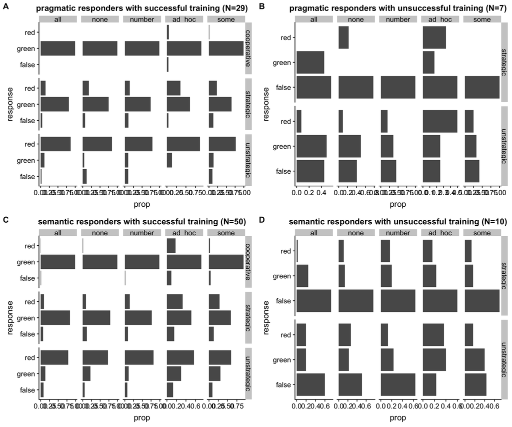

```r
prag_success = get_group_plot("pragmatic", 1)
prag_fail = get_group_plot("pragmatic", 0)
sem_success = get_group_plot("semantic", 1)
sem_fail = get_group_plot("semantic", 0)

plot_grid(
  prag_success,
  prag_fail,
  sem_success,
  sem_fail,
  labels = c("A", "B", "C", "D"),
  align = "h",
  ncol = 2) %>% show()
```

## Analysis: Proportion of ‘win-move’ choices

To address our research questions, we look at the data from the main sentence completion task for those participants who completed training successfully. We then record the proportion of “winning moves” for each tuple consisting of the participant, to co-player condition, the sentence type and the participant’s classification. If more than 70% of the choices in such a tuple are “winning moves” we consider this a clear majority of win-move choices.

```r
# filter and select the relevant bits for analysis
# code the responses as win/lose/opt_out
d_analysis = filter(d, trial_type == "sentence_completion") %>%
  filter(training_successful == 1) %>%
  mutate(
    rsp = relevel(factor(
      ifelse(coplayer_type == "unstrategic",
             case_when(response == "red" ~ "win",
                       response == "green" ~ "lose",
                       TRUE ~ "opt_out"),
             case_when(response == "green" ~ "win",
                       response == "red" ~ "lose",
                       TRUE ~ "opt_out"))),
      ref = "win"),
    condition = relevel(factor(condition), ref = "all"),
    item = number,
    win_move = ifelse(rsp == "win", 1, 0)
  ) %>%
  select(submission_id, item, coplayer_type, condition, tvj_semprag_type, rsp, win_move)


# threshold of minimal proportion of win-moves a player-condition typle
# needs to be counted as "majority-win-move" choice
winning_threshold = 0.7

# get the "win-move" proportions
d_win_prop = d_analysis %>%
  group_by(submission_id, coplayer_type, condition, tvj_semprag_type) %>%
  summarize(win_move_prop = mean(win_move),
            winner = win_move_prop > winning_threshold)
```

We then analyze the distribution of majority-win-choices as a function of co-player type, sentence type, and the participants’ semamtic-pragmatic choice types. To so so, we use a Bayesian logistic regression model and inspect the posterior distribution of coefficient values.

```r
prior <- c(prior_string("normal(0,10)", class = "b"))
model_win_prop = brm(
  formula = winner ~ coplayer_type * condition * tvj_semprag_type,
  family = "bernoulli",
  data = d_win_prop,
  prior = prior
)
```

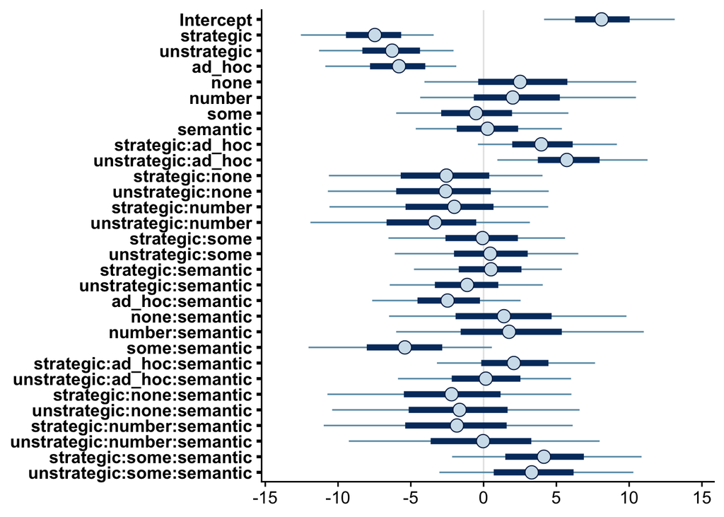

```r
post_samples = posterior_samples(model_win_prop) %>%
  as_tibble() %>%
  select( - lp__)
newcolnames = str_replace(names(post_samples), "b_", "") %>%
  str_replace("condition", "") %>%
  str_replace("coplayer_type", "") %>%
  str_replace("tvj_semprag_type", "")
names(post_samples) = newcolnames

bayesplot::mcmc_intervals(post_samples)
```